# INET 4061 Lab 10

## Julius Kintop

### 03/29/2023

# Overview

Sources: https://www.machinelearningplus.com/time-series/arima-model-time-series-forecasting-python/

https://towardsdatascience.com/find-the-order-of-arima-models-b4d99d474e7a

https://www.statsmodels.org/dev/generated/statsmodels.tsa.arima.model.ARIMA.html

https://www.statsmodels.org/dev/statespace.html

http://barnesanalytics.com/sarima-models-using-statsmodels-in-python/

https://machinelearningmastery.com/sarima-for-time-series-forecasting-in-python/

inspiration for grid search (SARIMA): https://machinelearningmastery.com/grid-search-arima-hyperparameters-with-python/

parser: https://machinelearningmastery.com/arima-for-time-series-forecasting-with-python/

# Data

The data has a good overview in this link:

https://nsidc.org/data/g02135/versions/3

```python
import numpy as np
import pandas as pd
import matplotlib.pyplot as plt
import seaborn as sns
```

```python
import os

# Get the current working directory
working_directory = os.getcwd()

# Print the working directory
print(working_directory)
```

```
/Users/juliuskintop/Downloads
```

```python
# Define the new working directory
new_working_directory = "/Users/juliuskintop/Downloads"

# Change the current working directory
os.chdir(new_working_directory)

# Verify that the working directory has been changed
current_directory = os.getcwd()
print(f"Current working directory: {current_directory}")
```

```
Current working directory: /Users/juliuskintop/Downloads
```

```python
dataframes = {}
for i in range(1,13):
    if i < 10:
        filename = f"N_0{i}_extent_v3.0.csv"
    else:
        filename = f"N_{i}_extent_v3.0.csv"
    dataframes[i] = pd.read_csv(filename)
```

```python
#Loading data into dataframe to be used,combine all 12 csv files into one dataframe so we have proper dataset with all 12 months
df = pd.concat(map(pd.read_csv, ['N_01_extent_v3.0.csv', 'N_02_extent_v3.0.csv','N_03_extent_v3.0.csv','N_04_extent_v3.0.csv','N_05_extent_v3.0.csv','N_06_extent_v3.0.csv','N_07_extent_v3.0.csv','N_08_extent_v3.0.csv','N_09_extent_v3.0.csv','N_10_extent_v3.0.csv','N_11_extent_v3.0.csv' ,'N_12_extent_v3.0.csv']))
#remove the spaces that appear in column headings
df.columns = df.columns.str.replace(' ', '')
#dropping bad rows from dataset
df = df[df['area'] != -9999.00]
#dropping columns we don't need
df=df.drop(['data-type','region','extent'], axis=1)
#create a unique time column to sort on
df["time"] = df["year"].apply(str) + "-" + df["mo"].apply(str).str.zfill(2)
#drop the old columns we don't need now
df=df.drop(['year', 'mo'], axis=1)
#make sure our new unique column is the index which is important for time series data (needs to be in order!)
df = df.set_index('time')
#sort it!
df = df.sort_values(by=['time'])
#make sure it's in order
df.head(50)
```

| time | area |
| --- | --- |
| 1978-11 | 9.04 |
| 1978-12 | 10.90 |
| 1979-01 | 12.41 |
| 1979-02 | 13.18 |
| 1979-03 | 13.21 |
| 1979-04 | 12.53 |
| 1979-05 | 11.11 |
| 1979-06 | 9.34 |
| 1979-07 | 6.69 |
| 1979-08 | 5.06 |
| 1979-09 | 4.58 |
| 1979-10 | 6.19 |
| 1979-11 | 8.37 |
| 1979-12 | 10.63 |
| 1980-01 | 11.94 |
| 1980-02 | 12.90 |
| 1980-03 | 12.99 |
| 1980-04 | 12.52 |
| 1980-05 | 10.96 |
| 1980-06 | 9.00 |
| 1980-07 | 6.53 |
| 1980-08 | 4.94 |
| 1980-09 | 4.87 |
| 1980-10 | 6.50 |
| 1980-11 | 8.73 |
| 1980-12 | 10.78 |
| 1981-01 | 11.91 |
| 1981-02 | 12.53 |
| 1981-03 | 12.71 |
| 1981-04 | 12.24 |
| 1981-05 | 10.99 |
| 1981-06 | 9.03 |
| 1981-07 | 6.31 |
| 1981-08 | 4.48 |
| 1981-09 | 4.44 |
| 1981-10 | 6.27 |
| 1981-11 | 8.31 |
| 1981-12 | 10.54 |
| 1982-01 | 12.19 |
| 1982-02 | 12.87 |
| 1982-03 | 13.07 |
| 1982-04 | 12.63 |
| 1982-05 | 11.17 |
| 1982-06 | 9.46 |
| 1982-07 | 6.87 |
| 1982-08 | 5.00 |
| 1982-09 | 4.43 |
| 1982-10 | 6.67 |
| 1982-11 | 9.06 |
| 1982-12 | 10.88 |

# Exploratory Data Analysis

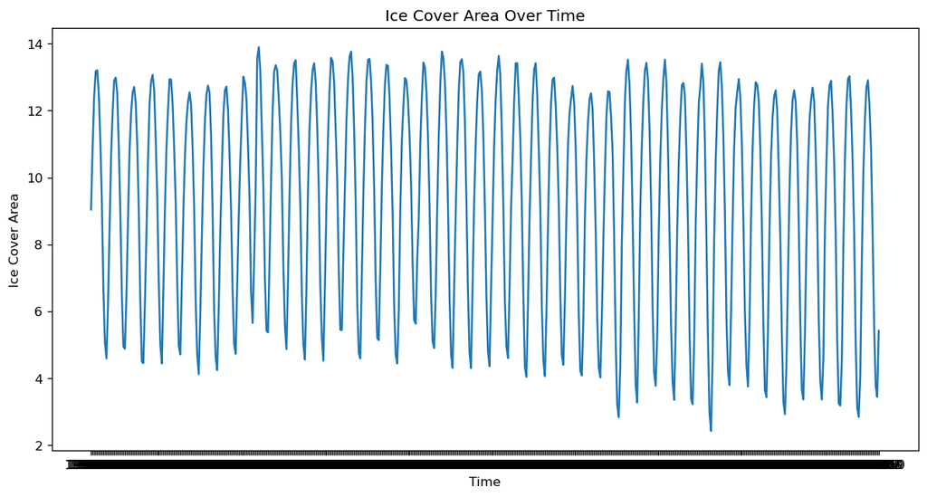

```python
plt.figure(figsize=(12, 6))
plt.plot(df['area'])
plt.xlabel('Time')
plt.ylabel('Ice Cover Area')
plt.title('Ice Cover Area Over Time')
plt.show()
```

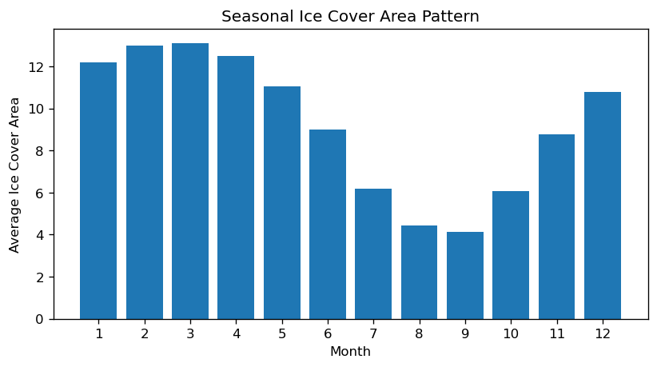

```python
df.index = pd.to_datetime(df.index, format="%Y-%m")
monthly_area = df.groupby(df.index.month).mean()

plt.figure(figsize=(8, 4))
plt.bar(monthly_area.index, monthly_area['area'])
plt.xlabel('Month')
plt.ylabel('Average Ice Cover Area')
plt.title('Seasonal Ice Cover Area Pattern')
plt.xticks(range(1, 13))
plt.show()
```

```python
df.describe()
```

|  | area |
| --- | --- |
| count | 513.000000 |
| mean | 9.272300 |
| std | 3.246864 |
| min | 2.410000 |
| 25% | 6.270000 |
| 50% | 9.950000 |
| 75% | 12.290000 |
| max | 13.900000 |

```python
df.index
```

```
DatetimeIndex(['1978-11-01', '1978-12-01', '1979-01-01', '1979-02-01',
               '1979-03-01', '1979-04-01', '1979-05-01', '1979-06-01',
               '1979-07-01', '1979-08-01',
               ...
               '2021-01-01', '2021-02-01', '2021-03-01', '2021-04-01',
               '2021-05-01', '2021-06-01', '2021-07-01', '2021-08-01',
               '2021-09-01', '2021-10-01'],
              dtype='datetime64[ns]', name='time', length=513, freq=None)
```

```python
df.isna().sum()
```

```
area    0
dtype: int64
```

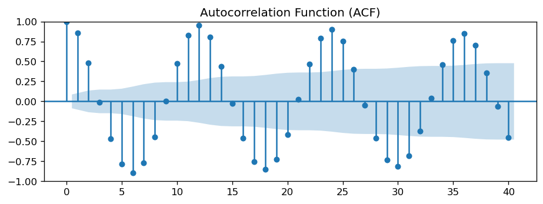

```python
from statsmodels.graphics.tsaplots import plot_acf, plot_pacf

# Plot ACF
plt.figure(figsize=(12, 5))
plot_acf(df["area"], lags=40, title="Autocorrelation Function (ACF)")
plt.show()
```

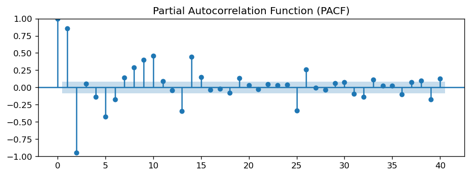

```python
# Plot PACF
plt.figure(figsize=(12, 5))
plot_pacf(df["area"], lags=40, title="Partial Autocorrelation Function (PACF)")
plt.show()
```

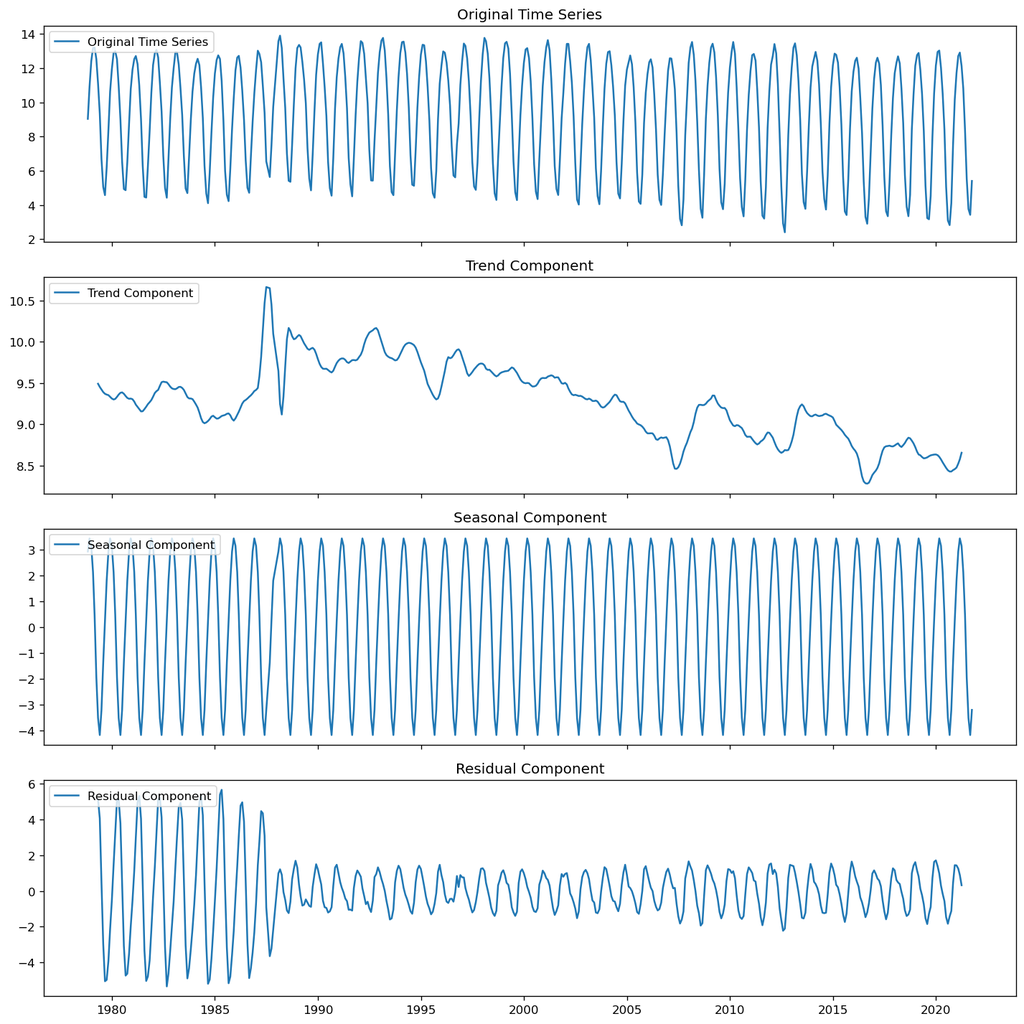

```python
from statsmodels.tsa.seasonal import seasonal_decompose
# Decompose the time series
decomposition = seasonal_decompose(df["area"], model="additive", period=12)

# Plot the decomposition components
fig, (ax1, ax2, ax3, ax4) = plt.subplots(4, 1, figsize=(12, 12), sharex=True)

# Plot the original time series
ax1.plot(df["area"], label="Original Time Series")
ax1.legend(loc="upper left")
ax1.set_title("Original Time Series")

# Plot the trend component
ax2.plot(decomposition.trend, label="Trend Component")
ax2.legend(loc="upper left")
ax2.set_title("Trend Component")

# Plot the seasonal component
ax3.plot(decomposition.seasonal, label="Seasonal Component")
ax3.legend(loc="upper left")
ax3.set_title("Seasonal Component")

# Plot the residual component
ax4.plot(decomposition.resid, label="Residual Component")
ax4.legend(loc="upper left")
ax4.set_title("Residual Component")

plt.tight_layout()
plt.show()
```

```python
train, test = df.iloc[:371, 0], df.iloc[371:, 0]
```

```python
train.describe()
```

```
count    371.000000
mean       9.464420
std        3.115433
min        2.820000
25%        6.515000
50%        9.950000
75%       12.350000
max       13.900000
Name: area, dtype: float64
```

```python
train.head()
```

```
time
1978-11-01     9.04
1978-12-01    10.90
1979-01-01    12.41
1979-02-01    13.18
1979-03-01    13.21
Name: area, dtype: float64
```

```python
train.tail()
```

```
time
2009-08-01     4.16
2009-09-01     3.76
2009-10-01     5.24
2009-11-01     8.36
2009-12-01    10.59
Name: area, dtype: float64
```

```python
test.tail()
```

```
time
2021-06-01    8.38
2021-07-01    5.55
2021-08-01    3.77
2021-09-01    3.43
2021-10-01    5.41
Name: area, dtype: float64
```

# ARIMA Model

In this section, we will use the ARIMA model, which is short for Autoregressive Integrated Moving Average, which combines three components: The Autoregressive (AR), Differencing (I), and Moving Average (MA) which help capture different patterns in time series data. The AR component models the correlation between an observation and previous (lagged) observations, denoted by 'p'. The Integrated (I) component makes the time series stationary, meaning the mean and variance do not change over time. The Moving Average (MA) component models the dependency between an observation and residual error from a moving average of lagged observations.

```python
# Determine Stationarity
# H0: time series is non-stationary
from statsmodels.tsa.stattools import adfuller
from numpy import log
result = adfuller(df.area.dropna())
print('ADF Statistic: %f' % result[0])
print('p-value: %f' % result[1])
```

```
ADF Statistic: -1.818274
p-value: 0.371427
```

We find that our time series is non-stationary, so we need to find the order of difference.

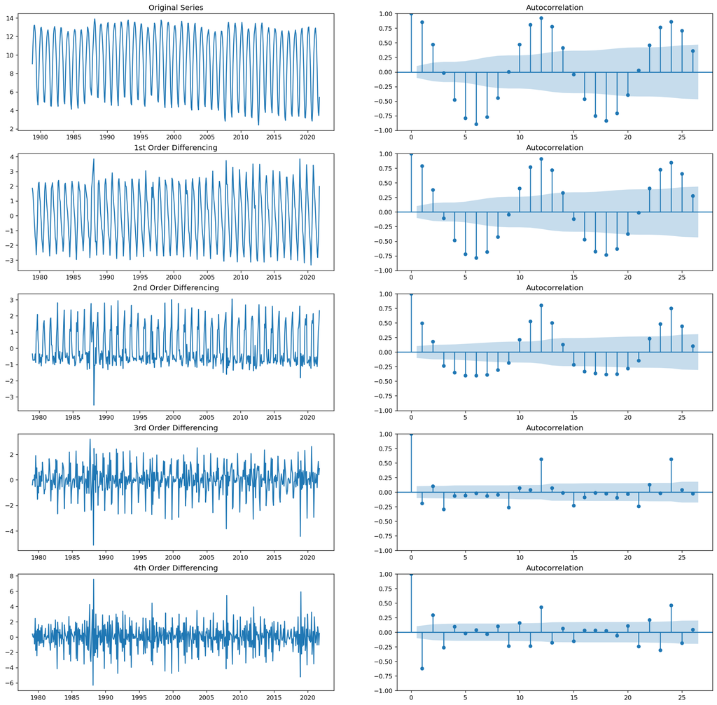

```python
from statsmodels.graphics.tsaplots import plot_acf, plot_pacf

# Original Series
fig, axes = plt.subplots(5, 2, figsize=(20,20))
axes[0, 0].plot(df.area); axes[0, 0].set_title('Original Series')
plot_acf(train, ax=axes[0, 1])

# 1st Differencing
axes[1, 0].plot(df.area.diff()); axes[1, 0].set_title('1st Order Differencing')
plot_acf(train.diff().dropna(), ax=axes[1, 1])

# 2nd Differencing
axes[2, 0].plot(df.area.diff().diff()); axes[2, 0].set_title('2nd Order Differencing')
plot_acf(train.diff().diff().dropna(), ax=axes[2, 1])

# 3rd Differencing
axes[3, 0].plot(df.area.diff().diff().diff()); axes[3, 0].set_title('3rd Order Differencing')
plot_acf(train.diff().diff().diff().dropna(), ax=axes[3, 1])

# 4th Differencing
axes[4, 0].plot(df.area.diff().diff().diff().diff()); axes[4, 0].set_title('4th Order Differencing')
plot_acf(train.diff().diff().diff().diff().dropna(), ax=axes[4, 1])

plt.show()
```

Based on the ACF plots, it looks like we can use the order of differencing parameter to be 3. The series may be over-differenced here, but it seems much better than the 1st and 2nd order differencing, so we will go with it.

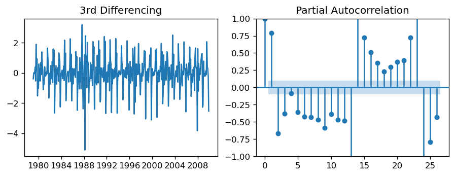

```python
# PACF plot of 3rd differenced series
plt.rcParams.update({'figure.figsize':(9,3), 'figure.dpi':120})

fig, axes = plt.subplots(1, 2)
axes[0].plot(train.diff().diff().diff()); axes[0].set_title('3rd Differencing')
axes[1].set(ylim=(0,5))
plot_pacf(train.diff().dropna(), ax=axes[1])

plt.show()
```

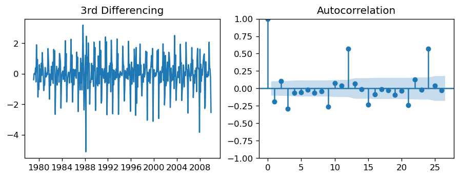

```python
plt.rcParams.update({'figure.figsize':(9,3), 'figure.dpi':120})

fig, axes = plt.subplots(1, 2)
axes[0].plot(train.diff().diff().diff()); axes[0].set_title('3rd Differencing')
axes[1].set(ylim=(0,1.2))
plot_acf(train.diff().diff().diff().dropna(), ax=axes[1])

plt.show()
```

Based on the ACF plot, we will also set the MA parameter to 2.

Now that we have the parameters of our ARIMA model set to (2, 3, 2) we can fit the model and predict values, then test the model.

```python
from statsmodels.tsa.arima.model import ARIMA
model = ARIMA(train, order=(2,3,2))
model_fit = model.fit()
print(model_fit.summary())
```

```
                               SARIMAX Results
==============================================================================
Dep. Variable:                   area   No. Observations:                  371
Model:                 ARIMA(2, 3, 2)   Log Likelihood                -495.801
Date:                Tue, 04 Apr 2023   AIC                           1001.602
Time:                        22:13:57   BIC                           1021.142
Sample:                             0   HQIC                          1009.365
                                - 371
Covariance Type:                  opg
==============================================================================
                 coef    std err          z      P>|z|      [0.025      0.975]
------------------------------------------------------------------------------
ar.L1         -0.4551      0.063     -7.211      0.000      -0.579      -0.331
ar.L2          0.5275      0.061      8.655      0.000       0.408       0.647
ma.L1         -0.0424      0.424     -0.100      0.920      -0.873       0.788
ma.L2         -0.9560      0.406     -2.354      0.019      -1.752      -0.160
sigma2         0.8551      0.352      2.431      0.015       0.166       1.545
===================================================================================
Ljung-Box (L1) (Q):                   2.82   Jarque-Bera (JB):                17.68
Prob(Q):                              0.09   Prob(JB):                         0.00
Heteroskedasticity (H):               1.06   Skew:                             0.11
Prob(H) (two-sided):                  0.76   Kurtosis:                         4.05
===================================================================================

Warnings:
[1] Covariance matrix calculated using the outer product of gradients (complex-step).
```

```python
model = ARIMA(train, order=(2,1,2))
results = model.fit()
print(results.summary())
```

```
                               SARIMAX Results
==============================================================================
Dep. Variable:                   area   No. Observations:                  371
Model:                 ARIMA(2, 1, 2)   Log Likelihood                -311.954
Date:                Tue, 04 Apr 2023   AIC                            633.907
Time:                        22:13:57   BIC                            653.475
Sample:                             0   HQIC                           641.680
                                - 371
Covariance Type:                  opg
==============================================================================
                 coef    std err          z      P>|z|      [0.025      0.975]
------------------------------------------------------------------------------
ar.L1          1.7169      0.009    191.261      0.000       1.699       1.735
ar.L2         -0.9876      0.008   -116.572      0.000      -1.004      -0.971
ma.L1         -1.7400      0.032    -54.317      0.000      -1.803      -1.677
ma.L2          0.7770      0.033     23.732      0.000       0.713       0.841
sigma2         0.3093      0.025     12.500      0.000       0.261       0.358
===================================================================================
Ljung-Box (L1) (Q):                  34.58   Jarque-Bera (JB):                47.26
Prob(Q):                              0.00   Prob(JB):                         0.00
Heteroskedasticity (H):               0.90   Skew:                             0.60
Prob(H) (two-sided):                  0.58   Kurtosis:                         4.27
===================================================================================

Warnings:
[1] Covariance matrix calculated using the outer product of gradients (complex-step).
```

After fitting two different ARIMA models, one with d = 3 and the other with d = 1, the model with d = 1 has a much lower AIC and BIC, so it is a better model. We will use that one

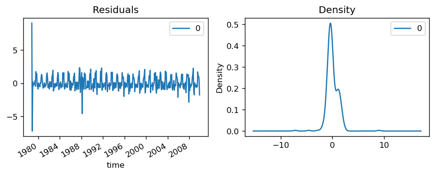

```python
# Plot residual errors
residuals = pd.DataFrame(model_fit.resid)
fig, ax = plt.subplots(1,2)
residuals.plot(title="Residuals", ax=ax[0])
residuals.plot(kind='kde', title='Density', ax=ax[1])
plt.show()
```

```python
len(test)
```

```
142
```

```python
test.index[0]
train.index = pd.to_datetime(train.index)
test.index = pd.to_datetime(test.index)
```

```
     predicted_mean
513        9.126979
514       11.852440
515       13.482852
516       14.440364
517       14.598971
```

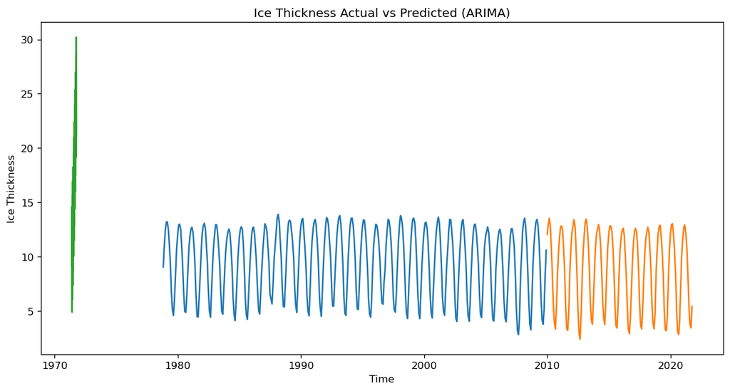

```python
# Make predictions for the test data
# definitely not right, out of time
predictions = results.forecast(steps=len(test))
pred_frame = pd.DataFrame(predictions)
print(pred_frame.head())


# Plot the actual values and predicted values on the same chart
fig, ax = plt.subplots(figsize=(12, 6))
ax.plot(train, label='Training Data')
ax.plot(test, label='Actual Test Data')
ax.plot(pred_frame["predicted_mean"], label='Predicted Test Data')
ax.set_xlabel('Time')
ax.set_ylabel('Ice Thickness')
ax.set_title('Ice Thickness Actual vs Predicted (ARIMA)')

plt.show()
```

```python
print("Actual value:", test[0])
```

```
Actual value: 12.04
```

```python
test.index[0]
```

```
Timestamp('2010-01-01 00:00:00')
```

# SARIMA Model

Next we will use SARIMA, which is an extension of ARIMA. SARIMA can handle seasonal patterns in time series data, while ARIMA cannot. In our case, there is a seasonal pattern in the data as seen in the exploratory data analysis section. There are new hyperparameters in the model to consider, not just the p, d, and q of ARIMA. The SARIMA-specific hyperparameters include P: the seasonal autoregressive order, D: seasonal difference order, Q: seasonal moving average order, and m: the number of time steps for a single seasonal period. The notation is specified as SARIMA(p,d,q)(P,D,Q)m.

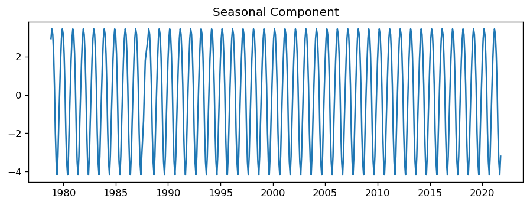

```python
decomposition = seasonal_decompose(df["area"], model="additive", period=12)

# Plot the seasonal component
plt.plot(decomposition.seasonal, label="Seasonal Component")
plt.title("Seasonal Component")
plt.show()
```

This is the seasonal component of the time series, as shown briefly earlier.

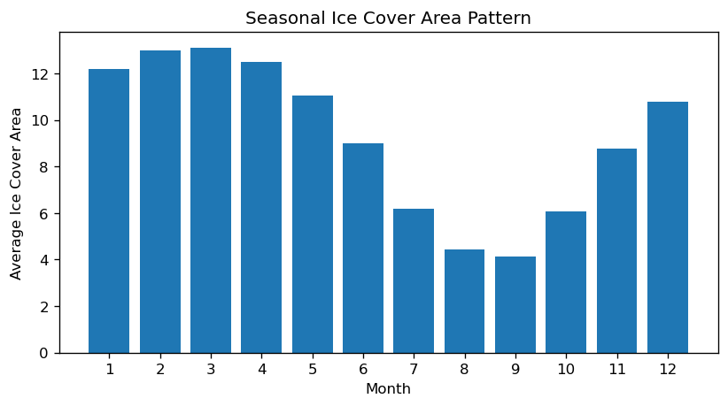

```python
plt.figure(figsize=(8, 4))
plt.bar(monthly_area.index, monthly_area['area'])
plt.xlabel('Month')
plt.ylabel('Average Ice Cover Area')
plt.title('Seasonal Ice Cover Area Pattern')
plt.xticks(range(1, 13))
plt.show()
```

```python
# use grid search to find optimal seasonal parameters
import itertools
from statsmodels.tsa.statespace.sarimax import SARIMAX

# Define the seasonal frequency (s) for your data
s = 12  # Assuming monthly data with a seasonal frequency of 12

# Define the p, d, and q parameters to take any value between 0 and 2
p = d = q = range(0, 3)
pdq = list(itertools.product(p, d, q))

# Define the seasonal P, D, and Q parameters to take any value between 0 and 1
P = D = Q = range(0, 2)
seasonal_pdq = [(x[0], x[1], x[2], s) for x in itertools.product(P, D, Q)]

# Find the best SARIMA model parameters based on the lowest AIC value
best_aic = np.inf
best_pdq = None
best_seasonal_pdq = None
best_model = None

for param in pdq:
    for param_seasonal in seasonal_pdq:
        try:
            # Fit a SARIMA model with the current parameter combination
            model = SARIMAX(df['area'], order=param, seasonal_order=param_seasonal)
            results = model.fit()

            # Check if the current model has a lower AIC value than the previous best model
            if results.aic < best_aic:
                best_aic = results.aic
                best_pdq = param
                best_seasonal_pdq = param_seasonal
                best_model = results
        except:
            continue

#print(f"Best SARIMA Model: PDQ = {best_pdq}, Seasonal PDQ = {best_seasonal_pdq}, AIC = {best_aic}")
```

[output not shown]

[output cut: 9 more lines]

[output not shown]

[output not shown]

[output cut: 31 more lines]

[output not shown]

[output not shown]

[output cut: 19 more lines]

[output not shown]

[output not shown]

[output not shown]

[output not shown]

[output not shown]

[output cut: 27 more lines]

[output not shown]

[output not shown]

[output not shown]

[output not shown]

[output not shown]

[output cut: 36 more lines]

[output not shown]

[output not shown]

[output not shown]

[output not shown]

[output not shown]

[output not shown]

[output not shown]

[output cut: 61 more lines]

[output not shown]

[output not shown]

[output cut: 19 more lines]

[output not shown]

[output not shown]

[output not shown]

[output not shown]

[output cut: 35 more lines]

[output not shown]

[output not shown]

[output not shown]

[output cut: 25 more lines]

[output not shown]

[output not shown]

[output not shown]

[output not shown]

[output not shown]

[output not shown]

[output not shown]

[output cut: 17 more lines]

[output not shown]

[output not shown]

[output cut: 11 more lines]

[output not shown]

[output not shown]

[output cut: 93 more lines]

[output not shown]

[output not shown]

[output not shown]

[output cut: 54 more lines]

[output not shown]

[output not shown]

[output not shown]

[output not shown]

[output cut: 25 more lines]

[output not shown]

[output not shown]

[output cut: 28 more lines]

[output not shown]

[output not shown]

[output cut: 11 more lines]

[output not shown]

[output not shown]

[output not shown]

[output not shown]